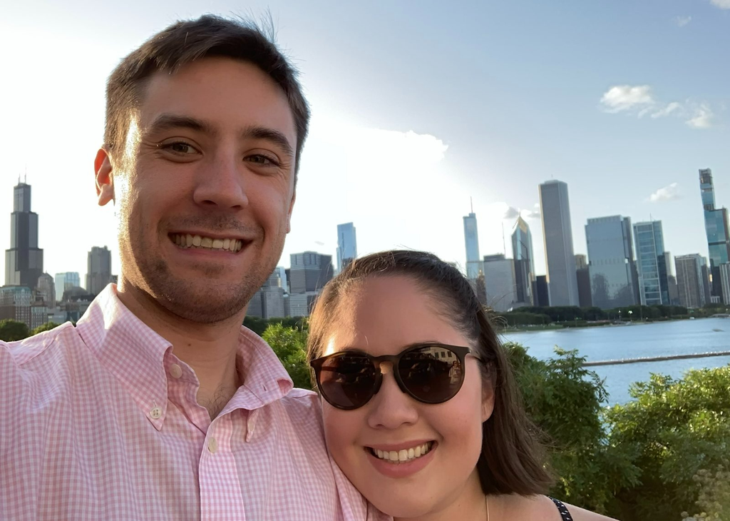

# June 25th, 2022

## Ceremony

[figure not shown]

4:30pm at Midwest Buddhist Temple, 435 W Menomonee St, Chicago, IL 60614

## Dinner

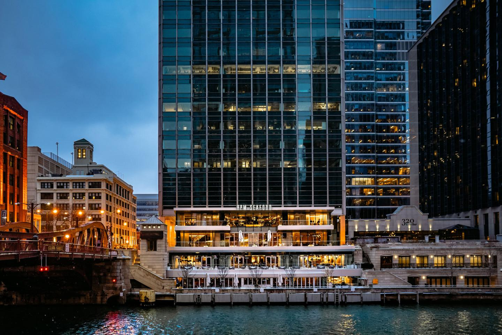

6:00pm at RPM Seafood, 317 N Clark St, Chicago, IL 60654

## The party continues…

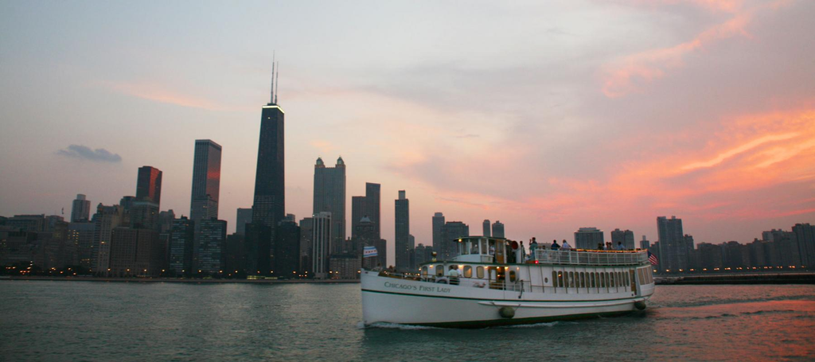

9:00pm on Chicago’s First Lady to watch the Navy Pier Fireworks, 112 E. Wacker Dr (on the Riverwalk between Columbus and Michigan). The boat will return to the dock at midnight.

## Transit and Parking

MBT is close to the Sedgwick Brown Line Station. From MBT to RPM Seafood, you could take the Brown Line to Merchandise Mart or #22 bus from Clark & Menomonee to LaSalle & Kinzie.

If you are staying in downtown Chicago, we recommend taking a taxi/Uber/Lyft between venues.

MBT has free parking in the lot (enter off West Willow Street) for the ceremony and neighborhood street parking is available until 6pm.

If you are not going on the boat, RPM Seafood has valet parking available. If you are going on the boat, please do not park at RPM Seafood. We recommend using an app like SpotHero to find local parking.